# Chapter 3

jim108@gmx.net

5/15/2020

## 3E1.

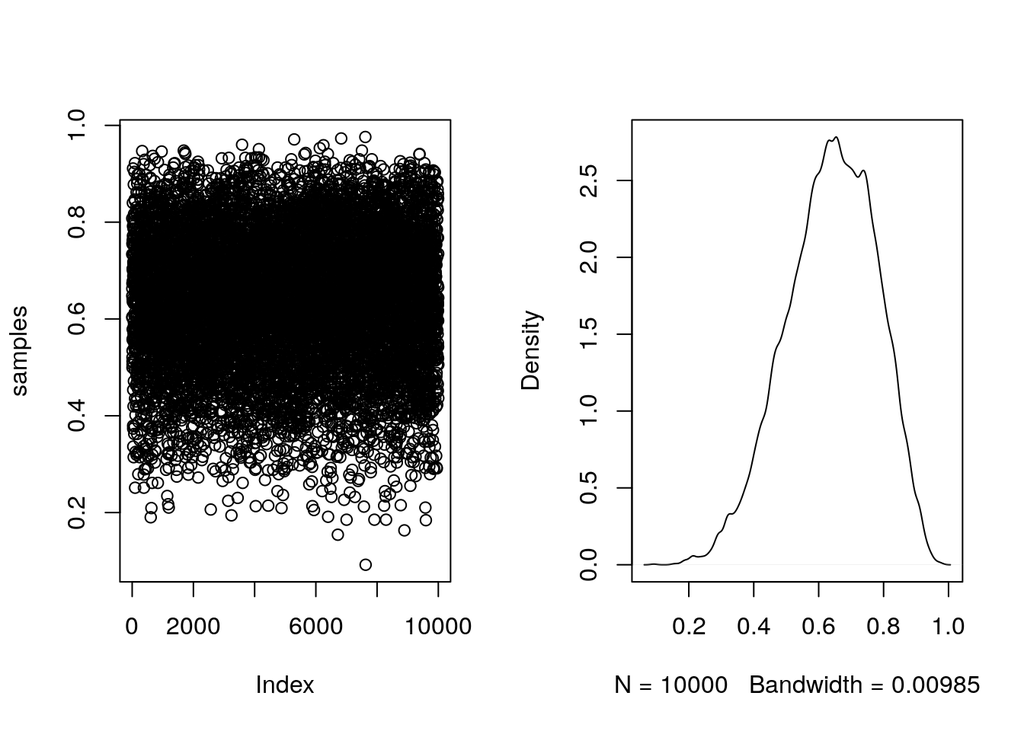

How much posterior probability lies below p = 0.2?

```r
mean(samples < 0.2)
```

```
## [1] 0.001
```

## 3E2.

How much posterior probability lies above p = 0.8?

```r
mean(samples > 0.8)
```

```
## [1] 0.1213
```

## 3E3.

How much posterior probability lies between p = 0.2 and p = 0.8?

```r
mean(samples > 0.2 & samples < 0.8)
```

```
## [1] 0.8777
```

## 3E4.

20% of the posterior probability lies below which value of p?

```r
quantile(samples,0.2)
```

```
##       20%
## 0.5193193
```

## 3E5.

20% of the posterior probability lies above which value of p?

```r
quantile(samples,0.8)
```

```
##       80%
## 0.7617618
```

## 3E6.

Which values of p contain the narrowest interval equal to 66% of the posterior probability?

```r
HPDI( samples , prob=0.66 )
```

```
##     |0.66     0.66|
## 0.5205205 0.7907908
```

## 3E7.

Which values of p contain 66% of the posterior probability, assuming equal posterior probability both below and above the interval?

```r
PI( samples , prob=0.66 )
```

```
##       17%       83%
## 0.5005005 0.7747748
```

## 3M1.

Given: Globe example: $k=8$, $n=15$.

Want: $P(p\mid k,n)$.

Sol.:

```r
get_globe_samples <- function(k,n){
  num_grid_points <- 1000
  p_grid <- seq( from=0 , to=1 , length.out=num_grid_points)
  prior <- rep(1,num_grid_points)
  likelihood <- dbinom( k , size=n , prob=p_grid )
  posterior <- likelihood * prior
  posterior <- posterior / sum(posterior)
  samples <- sample( p_grid , size=1e4 , replace=TRUE , prob=posterior )
  return(samples)
}
set.seed(3)
samples <- get_globe_samples(8, 15)
```

## 3M2.

Given: Globe example: $k=8$, $n=15$.

Want: Draw 10000 samples, 90% HPDI.

Sol.:

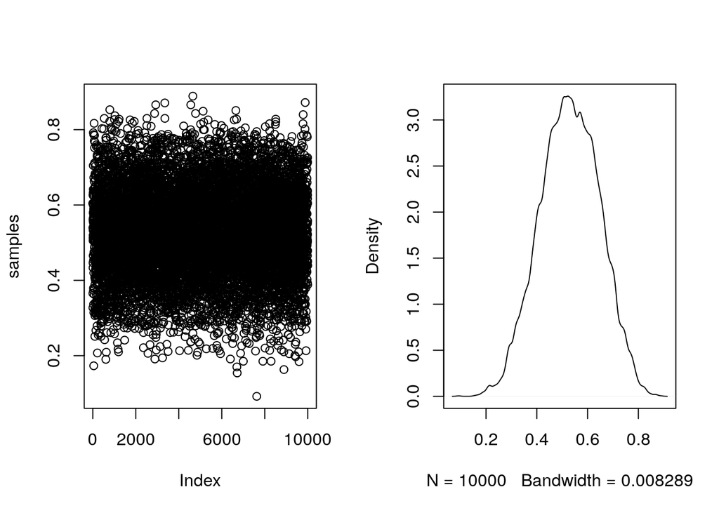

```r
par(mfrow=c(1,2))
plot( samples )
dens( samples )
```

```r
HPDI( samples , prob=0.90 )
```

```
##      |0.9      0.9|
## 0.3353353 0.7167167
```

## 3M3.

Given: Globe example: $k=8$, $n=15$.

Want: Simulate the distribution of samples, averaging over the posterior uncertainty in p.

Sol.:

```r
d15 <- rbinom(1e4, size=15, prob=samples)
mean(d15 == 8)
```

```
## [1] 0.1454
```

## 3M4.

Given: Globe example: $k=6$, $n=9$.

Want: Mean samples.

Sol.:

```r
d9 <- rbinom(10000, size=9, prob=samples)
mean(d9==6)
```

```
## [1] 0.1814
```

## 3M5.

Given: Use a prior that is zero below p = 0.5 and a constant above p = 0.5.

Want: Compare results with the prior before.

Sol.:

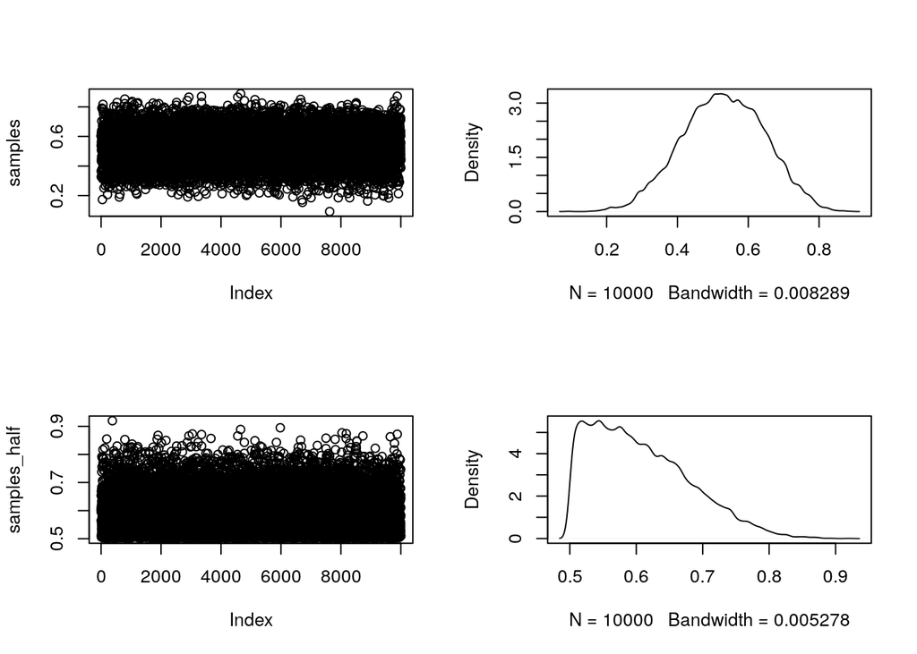

```r
get_globe_samples_half <- function(k,n){
  num_grid_points <- 1000
  p_grid <- seq( from=0 , to=1 , length.out=num_grid_points)
  prior <- ifelse( p_grid < 0.5, 0, 1)
  likelihood <- dbinom( k , size=n , prob=p_grid )
  posterior <- likelihood * prior
  posterior <- posterior / sum(posterior)
  samples <- sample( p_grid , size=1e4 , replace=TRUE , prob=posterior )
  return(samples)
}

set.seed(3)
samples_half <- get_globe_samples_half(8, 15)
par(mfrow=c(2,2))
plot( samples )
dens( samples )
plot( samples_half )
dens( samples_half )
```

```r
HPDI( samples , prob=0.90 )
```

```
##      |0.9      0.9|
## 0.3353353 0.7167167
```

```r
HPDI( samples_half , prob=0.90 )
```

```
##      |0.9      0.9|
## 0.5005005 0.7127127
```

```r
d15 <- rbinom(1e4, size=15, prob=samples)
mean(d15 == 8)
```

```
## [1] 0.1454
```

```r
d15_half <- rbinom(1e4, size=15, prob=samples_half)
mean(d15_half == 8)
```

```
## [1] 0.1564
```

```r
dumdata <- rbinom(10000, size=9, prob=samples)
mean(dumdata==6)
```

```
## [1] 0.1785
```

```r
dumdata_half <- rbinom(10000, size=9, prob=samples_half)
mean(dumdata_half==6)
```

```
## [1] 0.2374
```

```r
get_pi_width <- function(samples){
  pi <- PI(samples,prob = 0.99)
  w <- pi[2] - pi[1]
  return(w)
}
get_pi_width(samples)
```

```
##      100%
## 0.5675676
```

```r
get_globe_samples_tight <- function(k,n){
  num_grid_points <- 1000
  p_grid <- seq( from=0 , to=1 , length.out=num_grid_points)
  prior <- ifelse( p_grid < 0.5 | p_grid > 0.55, 0, 1)
  likelihood <- dbinom( k , size=n , prob=p_grid )
  posterior <- likelihood * prior
  posterior <- posterior / sum(posterior)
  samples <- sample( p_grid , size=1e4 , replace=TRUE , prob=posterior )
  return(samples)
}
set.seed(100)
samples <- get_globe_samples_tight(8,15)
get_pi_width(samples)
```

```
##       100%
## 0.04904905
```

## 3H1.

Which parameter value maximizes the posterior probability?

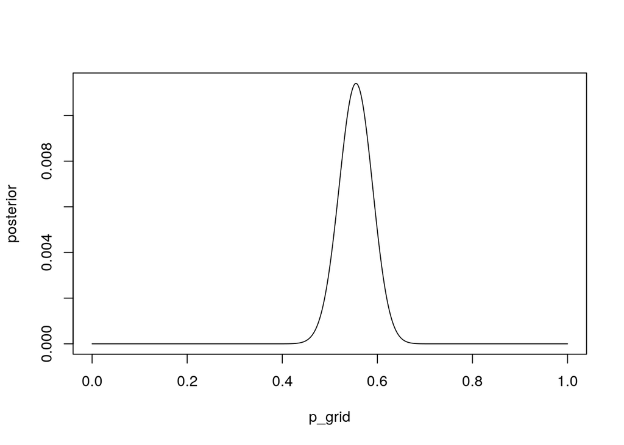

```r
num_boys <- sum(birth1) + sum(birth2)
num_children <- length(birth1) + length(birth2)

get_posterior <- function(k,n, p_grid){
  num_grid_points <- length(p_grid)
  prior <- rep(1,num_grid_points)
  likelihood <- dbinom( k , size=n , prob=p_grid )
  posterior <- likelihood * prior
  return(posterior / sum(posterior))
}
p_grid <- seq( from=0 , to=1 , length.out=1000)
posterior <- get_posterior(num_boys, num_children, p_grid)
plot(x = p_grid, y = posterior, type = "l")
```

```r
map <- p_grid[ which.max(posterior) ]
map
```

```
## [1] 0.5545546
```

## 3H2.

10000 samples. Use these samples to estimate the 50%, 89%, and 97% highest posterior density intervals.

```r
set.seed(123)
samples <- sample( p_grid , size=1e4 , replace=TRUE , prob=posterior )
for(w in c(.5, .89, .97)){
  hpi = HPDI(samples, w)
  print(sprintf("HPDI %d%% [%.2f, %.2f]",w*100, hpi[1], hpi[2]))
}
```

```
## [1] "HPDI 50% [0.53, 0.57]"
## [1] "HPDI 89% [0.50, 0.61]"
## [1] "HPDI 97% [0.48, 0.63]"
```

## 3H3.

Use rbinom to simulate 10,000 replicates of 200 births. You should end up with 10,000 num- bers, each one a count of boys out of 200 births. Compare the distribution of predicted numbers of boys to the actual count in the data (111 boys out of 200 births).

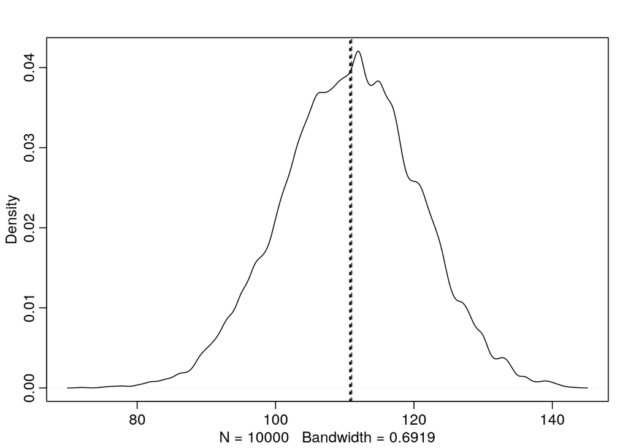

```r
set.seed(123)
d <- rbinom(1e4, size=200, prob=samples)
par(mfrow=c(1,1))
dens(d)
abline(v = num_boys, lty=2)
abline(v = mean(d), lty=3, lwd=2)
```

## 3H4.

Compare 10,000 counts of boys from 100 simulated first borns only to the number of boys in the first births.

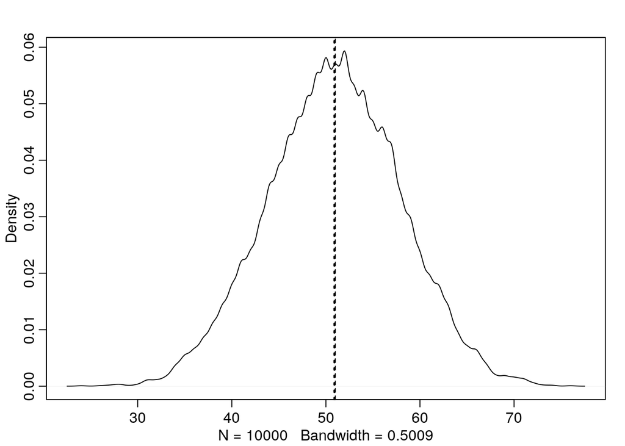

```r
posterior <- get_posterior(sum(birth1), length(birth1), p_grid)
set.seed(123)
samples <- sample( p_grid , size=1e4 , replace=TRUE , prob=posterior )
d <- rbinom(1e4, size=100, prob=samples)
par(mfrow=c(1,1))
dens(d)
abline(v = sum(birth1), lty=2)
abline(v = mean(d), lty=3, lwd=2)
```

```r
set.seed(123)
d <- rbinom(1e4, size=100, prob=samples)
par(mfrow=c(1,2))
print(sprintf("Simulated first born boys: %.f.",mean(d)))
```

```
## [1] "Simulated first born boys: 51."
```

```r
print(sprintf("Actual first born boys: %.f.",sum(birth1)))
```

```
## [1] "Actual first born boys: 51."
```

## 3H5.

Compare 10,000 simulated counts of boys to only those second births that followed girls.

```r
birth1_female_idxs <- birth1 == 0
birth2_birth1_female <- birth2[birth1_female_idxs]
num_birth1_female <- sum(birth1_female_idxs)

posterior <- get_posterior(num_birth1_female, length(birth1), p_grid)
set.seed(123)
samples <- sample( p_grid , size=1e4 , replace=TRUE , prob=posterior )
d <- rbinom(1e4, size=100, prob=samples)

print(sprintf("Simulated second born boys: %.f.",mean(d)))
```

```
## [1] "Simulated second born boys: 49."
```

```r
print(sprintf("Actual second born boys of first born females: %.f.",sum(birth2_birth1_female)))
```

```
## [1] "Actual second born boys of first born females: 39."
```